# Supporting Information 3

Disparate estimates of intrinsic productivity for Antarctic krill (Euphausia superba) across small spatial scales, under a rapidly changing ocean.

Mardones, M; Jarvis Mason, E.T.; Santa Cruz, F.; Watters, G.; Cárdenas, C.A

03 April, 2025

```r
# Cargar paquetes necesarios
library(LBSPR)
library(dplyr)
```

```r
library(ggplot2)
library(egg)
```

# Methodological Approach: Operating Model Construction

To evaluate the performance of the Length-Based Spawning Potential Ratio (LBSPR) model in estimating fishing mortality (*F*) and Spawning Potential Ratio (*SPR*) in krill (*Euphausia superba*), we developed an Operating Model (OM) that simulates population dynamics under different fishing pressures. The OM provides a controlled environment to generate synthetic length-frequency data, allowing us to assess the accuracy and bias of LBSPR estimates.

### Population Dynamics Simulation

The population was modeled using a size-structured framework based on the von Bertalanffy growth function (VBGF):

$$L_t = L_{\infty} \left(1 - e^{-k(t - t_0)}\right)$$

where:  
- $L_t$ is the length at age $t$,  
- $L_{\infty}$ is the asymptotic maximum length,  
- $k$ is the growth coefficient,  
- $t_0$ is the theoretical age at length zero.

### Generation of Length-Frequency Data

The OM generated synthetic length-frequency data by sampling individuals from the simulated population at different time steps. The sampling process mimicked empirical fisheries-dependent and fisheries-independent data collection.

We applied sampling variability to reflect realistic observation errors and deviations due to gear selectivity.

### Estimation Procedure Using LBSPR

The synthetic length data were analyzed using the LBSPR framework (R package *LBSPR*). The model estimated:  
1. Fishing mortality (*F*)  
2. Spawning Potential Ratio (*SPR*)

The estimated values were compared against true values from the OM to assess bias and accuracy.

### Interpretation of Results

- If estimates align with true values, LBSPR is accurate and unbiased.
- If estimates consistently overestimate or underestimate $F$ and $SPR$, LBSPR exhibits systematic bias.
- Performance under different exploitation levels highlights the robustness of LBSPR in krill stock assessments.

## MO

```r
# Definir Parámetros del Krill
set.seed(123)
Linf <- 60     # Longitud asintótica (mm)
k <- 0.4       # Coeficiente de crecimiento
t0 <- -0.5     # Edad a L=0
M <- 0.4       # Mortalidad natural
F_scenarios <- seq(0,1.5,0.5)  # Diferentes niveles de explotación
years <- 30    # Simular 30 años

# 2️⃣ Función para Simular Población
simulate_population <- function(F, years) {
  ages <- sample(seq(0, 8, by = 0.1), size = 5000, replace = TRUE)  # Distribución de edades
  lengths <- Linf * (1 - exp(-k * (ages - t0)))  # Crecimiento
  survival <- exp(- (M + F) * ages)  # Mortalidad natural + pesca

  # Generar estructura de tallas final
  krill_pop <- data.frame(Age = ages, Length = lengths, Survival = survival) %>%
    filter(runif(n()) < Survival)  # Muestreo de supervivientes

  return(krill_pop)
}

# 3️⃣ Aplicar Modelo LBSPR y Evaluar Sesgo
evaluate_LBSPR <- function(F) {
  krill_data <- simulate_population(F, years)  # Simula población

  # Simular muestreo de captura
  sampled_data <- krill_data %>% sample_n(300)

  # Configurar parámetros del modelo LBSPR
  LB_obj <- new("LB_pars")
  LB_obj@Linf <- Linf
  LB_obj@MK <- M / k
  LB_obj@L50 <- 35  # Longitud media de madurez
  LB_obj@L95 <- 50  # Longitud al 95% de madurez

  # Crear objeto de longitudes
  LB_data <- new("LB_lengths")
  LB_data@LMids <- seq(0, Linf, by = 2)

  # Crear histograma de longitudes
  hist_data <- hist(sampled_data$Length, breaks = LB_data@LMids, plot = FALSE)$counts
  LB_data@LData <- matrix(hist_data, ncol = 1)

  # 🔹 Solución del error de "Years must be numeric"
  LB_data@Years <- 1  # Definir número de años
  LB_data@NYears <- 1

  # Ajustar modelo LBSPR
  LB_fit <- LBSPRfit(LB_obj, LB_data)

  # Guardar resultados
  return(data.frame(F_real = F, F_est = LB_fit@FM, SPR_real = exp(-F), SPR_est = LB_fit@SPR))
}



# 4️⃣ Evaluar Sesgo en Distintos Escenarios
results <- lapply(F_scenarios, evaluate_LBSPR) %>% bind_rows()
```

[output not shown]

[output not shown]

[output not shown]

[output not shown]

[output not shown]

[output not shown]

[output not shown]

[output not shown]

[output not shown]

[output not shown]

[output not shown]

[output not shown]

[output not shown]

[output not shown]

[output not shown]

[output not shown]

[output not shown]

[output not shown]

[output not shown]

[output not shown]

[output not shown]

[output not shown]

[output not shown]

[output not shown]

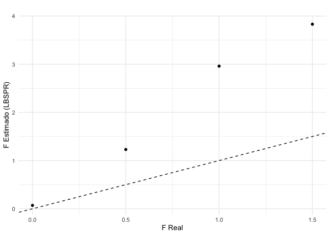

```r
# 5️⃣ Visualizar Resultados
Fses <- ggplot(results, aes(x = F_real, y = F_est)) +
  geom_point() +
  geom_abline(slope = 1, intercept = 0, linetype = "dashed") +
  labs(x = "F Real", y = "F Estimado (LBSPR)", title = "") +
  theme_minimal()
Fses
```

¿Qué representa el gráfico?  
- Eje X (F Real): Valores reales de la mortalidad por pesca utilizados en la simulación.  
- Eje Y (F Estimado - LBSPR): Valores de F estimados por el modelo LBSPR.  
- Línea discontinua: Representa la relación ideal `F estimado = F real`, es decir, una estimación sin sesgo.

¿Cómo interpretar la relación entre los puntos y la línea?  
- Si los puntos están sobre la línea, LBSPR estima correctamente F.  
- Si los puntos están por debajo de la línea, LBSPR subestima F.  
- Si los puntos están por encima de la línea, LBSPR sobreestima F.

Posibles causas del sesgo en la estimación de F  
Este sesgo creciente sugiere que LBSPR sobrestima la mortalidad por pesca cuando la explotación es alta. Algunas posibles razones:

1. Selección errónea de parámetros de crecimiento y longevidad
   - Si la población simulada tiene crecimiento más rápido o longevidad mayor a la asumida en LBSPR, el modelo puede interpretar que hay una mortalidad por pesca mayor de la real.
2. Errores en la distribución de tallas de la muestra
   - Si la muestra tiene un sesgo hacia individuos pequeños, LBSPR puede interpretar que la mortalidad por pesca es mayor de la real, ya que ve menos individuos grandes.
3. LBSPR puede no funcionar bien en escenarios de alta explotación
   - LBSPR está diseñado para poblaciones en equilibrio. En escenarios de sobrepesca extrema, puede no capturar bien la dinámica de la población y exagerar la mortalidad por pesca.

### Conclusión y recomendaciones

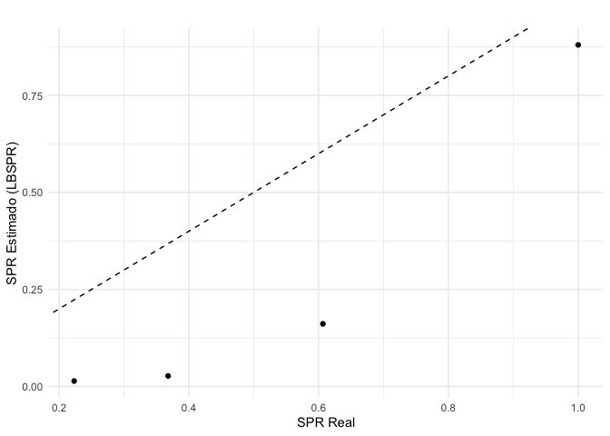

```r
sprses <- ggplot(results, aes(x = SPR_real, y = SPR_est)) +
  geom_point() +
  geom_abline(slope = 1, intercept = 0, linetype = "dashed") +
  labs(x = "SPR Real", y = "SPR Estimado (LBSPR)", title = "") +
  theme_minimal()
sprses
```

Este gráfico muestra el sesgo en la estimación del Spawning Potential Ratio (SPR) usando el modelo LBSPR. Vamos a interpretarlo:

¿Qué representa el gráfico? - Eje X (SPR Real): Valores reales de SPR usados en la simulación. - Eje Y (SPR Estimado - LBSPR): Valores de SPR estimados por el modelo LBSPR. - Línea discontinua: Representa la relación ideal donde `SPR estimado = SPR real`, es decir, sin sesgo.

¿Cómo interpretar la relación entre los puntos y la línea diagonal? - Si los puntos están sobre la línea, LBSPR estima correctamente el SPR. - Si los puntos están por debajo de la línea, significa que LBSPR subestima el SPR. - Si los puntos están por encima de la línea, LBSPR sobreestima el SPR.

Interpretación y Posibles Causas del Sesgo La subestimación del SPR en valores bajos puede deberse a: 1. Problemas con la selectividad de la pesca: Si los datos de tallas tienen pocos individuos grandes, el modelo puede inferir erróneamente que la población está más explotada de lo que realmente está. 2. Suposiciones del modelo LBSPR: LBSPR asume una estructura de crecimiento y selectividad fija. Si la realidad es diferente (por ejemplo, crecimiento más rápido o selectividad variable), esto puede inducir sesgo. 3. Tamaño de muestra insuficiente: Si hay poca información sobre individuos maduros en los datos simulados, LBSPR podría malinterpretar la relación longitud-madurez y subestimar el SPR. 4. Efecto de una mortalidad por pesca alta: En escenarios donde la mortalidad por pesca es alta, el modelo puede interpretar erróneamente que la población tiene menor capacidad reproductiva de lo que realmente tiene.

Conclusión - LBSPR estima bien el SPR en valores altos pero subestima fuertemente en valores bajos. - Este sesgo implica que en poblaciones sobreexplotadas LBSPR podría indicar una situación peor de la real, lo que podría llevar a una sobreestimación de la necesidad de reducción de esfuerzo pesquero. - Es importante hacer pruebas de sensibilidad variando: - Selectividad y mortalidad por pesca en las simulaciones. - Distribución de tallas en la muestra. - Número de iteraciones para evaluar estabilidad de las estimaciones.